# Foreign Aid 2

Credit, Service Delivery, and Accountability

Carolina Torreblanca

University of Pennsylvania

**Global Development**: Intermediate Topics in Politics, Policy, and Data

PSCI 3200 - Spring 2026

# Logistics

## Assignments

- Today
  - Cruz (2016)
  - Brief History of Non-State Service Provision
  - Bold et al. (2018)
- Friday
  - Data Assignment 1 due
  - Submit to Caro and I by Slack
- Monday (4/14)
  - Foreign Aid Obituary
  - I’ll figure out the readings tomorrow…

## Agenda

1. Cruz (2016)
2. Bold et al. (2018)
3. Final Questions: Data Assignment 1

# Cruz (2016)

## Foreign Aid and Accountability

**Standard channels for political manipulation**

- Distribution of aid: Divert resources from needy to strategically valuable communities (clientelism)
- Reallocation of budgets: Divert resources from development (fungibility)

## Foreign Aid and Accountability

**Donor strategies to avoid manipulation:**

- Project aid
- Channel through NGOs or direct transfers
- Generally cut government actors out of the process

## Three Questions

**Three questions**

1. Do citizens perceive foreign aid projects?
2. How do politicians claim credit?
3. Under what conditions are they successful?

**Sources of updating**

- Credit for welfare improvement
- More likely to secure future projects

## Research Design

- Research question: Can local politicians claim undue credit for the aid projects to boost their re-election prospects
- Allocation of projects: Eligibility determined by poverty threshold
- Least likely design for credit misattribution:
  - Low chance for political influence on distribution
  - Minimal ability to reallocate budget in response

## Undeserved Credit Claiming

- What is undeserved credit claiming?
  - Politicians claiming credit for projects they had no role in securing
- Mechanism:
  - Exploiting the lack of transparency and information among voters
- Implications:
  - Undermines incentives to improve welfare

## Findings

- Election impact: 12% increase in re-election chances
- Increased visits: Politicians visited project sites more frequently to appear involved
- Political credit: Mayors are credited for funding or initiating projects even when respondents knew of other funding sources

## Policy Implications

- Designing Aid Projects: Importance of transparency and community involvement to minimize undeserved credit claiming
- Voter Education: Enhancing voters’ understanding of aid processes to better hold politicians accountable
- Involvement: Giving opportunities to contribute makes credit deserved

# Brief History of Non-State Service Provision

## Service Delivery & The State

**What do states do?** (Hoffman, 2015)

- Monopolize violence
- Levy taxes
- Obtain the assent of the population

**Why is public service delivery (PSD) important?**

- Promotes economic growth
- Improves welfare of citizens

## The Social Contract

**Mutual reliance between states and citizens**

- States need tax revenue
- Citizens need public services
  - Provision of clean water accounts for 60% of the increase in life expectancy in the United States between 1850 and 1950 (Troesken 2001).

## The Social Contract

**Virtuous cycle between taxation, PSD, and state capacity**

- Taxation $\Rightarrow$ citizen demand for PSD
- Government PSD $\Rightarrow$ citizen compliance with taxation
- Citizen compliance with taxation $\Rightarrow$ increased state capacity
- Citizen reliance on PSD $\Rightarrow$ political accountability (Hoffman and Gibson 2005)

## The Fiscal Exchange

**How does this work in social contexts without direct taxation?**

- Compliance obtains when people expect that services will be delivered
- Compliance is *conditional*

**Norm-driven social contract emergence**

- Tax morale and civic duty
- Compliance is *internalized*

## Historical Service Delivery in Africa

**Service delivery in the pre-colonial period**

- Pre-colonial African states did not engage in extensive service delivery (Herbst 2000)
  - States weren’t geographically bounded
- Christian missions were (kinda) the first service providers
  - Emphasis on literacy and formalizing indigenous languages
  - Competing with traditional healers (Chirwa 2016)

## Historical Service Delivery in Africa

**Colonial approaches to service delivery**

- Traditional medicine was outlawed (Chirwa 2016)
- The church is “cemented” as the primary service provider (Jennings 2014)
  - **Tanzania at the end of the colonial period**
  - Church operated 81% of primary health facilities
  - Church-operated schools outnumbered government schools 4-to-1

## Historical Service Delivery in Africa

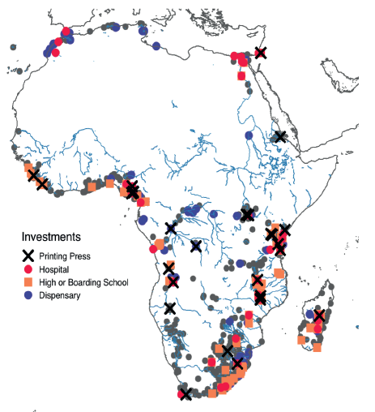

## Historical Service Delivery in Africa

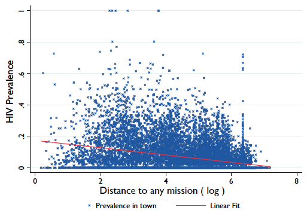

## Historical Service Delivery in Africa

**Post-colonial period**

- Post-colonial African states nationalized service delivery infrastructure and increased spending (Bates 1981)
  - **Kenya’s Civil Services** (Young 1988)
  - 1945: 14,000; 1955: 45,000; 1978: 170,000
- Commodity boom $\Rightarrow$ commodity bust
- Structural adjustment: **Kenya’s Health Spending** (J. Brass 2014)
  - 1980: $9.8 million; 1993: 6.2 million; 1996: 3.6 million

## The Re-Entry of Non-State Providers

*In 2007, 9% and 16% of US economic engagement with developing countries has been Official Development Assistance and private philanthropy respectively* (Kapur and Whittle 2009).

## The Re-Entry of Non-State Providers

[figure not shown]

## The Re-Entry of Non-State Providers

**Faith Based Organizations (FBOs)** (Green et al. 2002)

- Church “umbrella” organizations (ex. Uganda Protestant Medical Bureau)
  - Less aid (Reinikka and Svensson 2010), more user-fees (Munthali et al. 2015)
  - Cost-sharing with government
  - Uganda: 45% of the hospital beds; ⅓ of the country’s health workers (Tumwesigye 2013)
- International religious FBOs (ex. World Vision)
  - Operate more like secular NGOs

## The Re-Entry of Non-State Providers

**Malawi: Number of health facilities**

| Year | Gov | FBO | NGO |
| --- | --- | --- | --- |
| 2005 | 426 | 160 | 32 |
| 2008 | 545 | 167 | 70 |
| 2013 | 478 | 167 | 57 |

## The Re-Entry of Non-State Providers

**Kenya: Number of health facilities**

| Year | Gov | FBO | NGO |
| --- | --- | --- | --- |
| 2007 | 2,445 | 1,060 | 83 |
| 2012 | 4,043 | 998 | 218 |
| 2014 | 4,637 | 1,071 | 346 |

## Regions

[figure not shown]

## Non-governmental Organizations

**What are NGOs?**

- Private, non-profit organizations that aim to improve societal well-being through service delivery
- Provide free services, strengthen existing social infrastructure
- Receive most of their funding from foreign aid contracts (Fafchamps and Owens 2009; J. N. Brass 2012)
- Marie Stopes Uganda: Provided 75% of the Intrauterine Devices distributed in Uganda between 2006 and 2011

## Non-governmental Organizations

**Who do NGOs serve?**

- Target needy communities
- Target convenient communities
- “Pragmatic saints” (J. N. Brass 2012)

## Citizen Attitudes on NGOs

- Kenya: 70% of respondents said NGOs “have the interests of the people in mind” (34% for government) (J. Brass 2016).
- Tanzanian: 81% report that NGOs have “benefited” their community (Jivani 2010).
- Malawi: 60% agree that “Development NGOs provide services than cannot be provided by any other agency”; 68% consider NGOs to be effective (Jamali 2014).
- Liberia: 23% of respondents trust government but 72% trust NGOs; 72% describe government as corrupt, but 19% describe NGOs as corrupt (Tsai, 2017).

## NGOs & Politics

**NGO service delivery may weaken the ‘Fiscal Link’**

- Reduce reliance of government on taxation
- Reduce reliance on citizens on PSD
- Weaken the link between government performance and citizen welfare

**NGO service delivery may undermine accountability**

- Politicians get credit for NGO PSD
- NGOs make people more apolitical about government PSD

## NGOs & Politics

**NGOs as complements to the state** (J. Brass 2014)

- Joint implementation / co-production
  - Learning
  - Resource sharing
- Participation in government decision making
  - Lobbying for policy-changes
  - Transmitting information on citizen preferences
- Integration of NGOs into government plans

## The Limitations of NGOs

[output not shown]

# Bold et al. (2018)

## Scaling Up Education Reforms

**Treatment: Hiring contract teachers to improve text scores**

1. Smaller class sizes
2. Higher motivation

**Complicating Factors:**

1. Scale: the size of the program
2. Implementation: who is administering

## Context

**What’s different about contract teachers?**

- Lower cost
- Similar qualifications
- Different profile
  - Selection (firing)
  - Incentives (pay and retention)

## Scaling Up Education Reforms

**Random assignment of:**

- Government vs NGO implementation
- SMC Training
- Structure of contract
  - Local vs central control of hiring/firing
  - Low vs High Salary

## Research Design

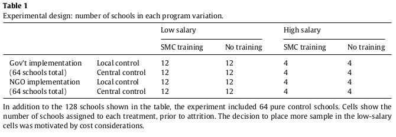

## Research Design

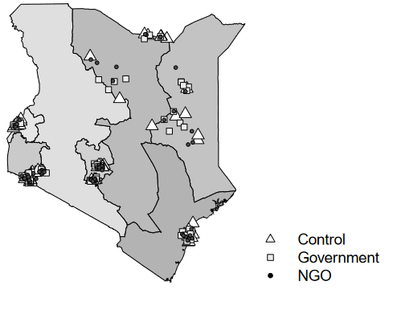

## Findings

- NGO implementation increased test scores
- Government implementation had no effect
  - Teacher quality: No
  - Monitoring: No
  - Bureaucratic delays in payment: Yes (⅓ of effect)
  - Political economy factors: Yes (credible enforcement of contracts)

**What does this tell us about the limitations of NGOs?**

# U.S. Foreign Aid: An Obituary

## Arenas

1. Health
2. Democracy and governance
3. Soft Power

## Health

- HIV: 20.6 million people (600k children) no longer receiving treatment
- Tuberculosis: 10.6 million cases and 2.2 million deaths will not be prevented
- Nutrition: HKI has stopped a program that provides nutrition for 5.6 million children
- Nutrition: In Sudan, ~80% of emergency food kitchens are closed
- Nutrition: In Ethiopia, foods to treat ~1 million severely malnourished children will run out by May

## Health

[figure not shown]

## Health (Gibson et al., 2025)

The impact of aid sanctions on maternal and child mortality, 1990–2019

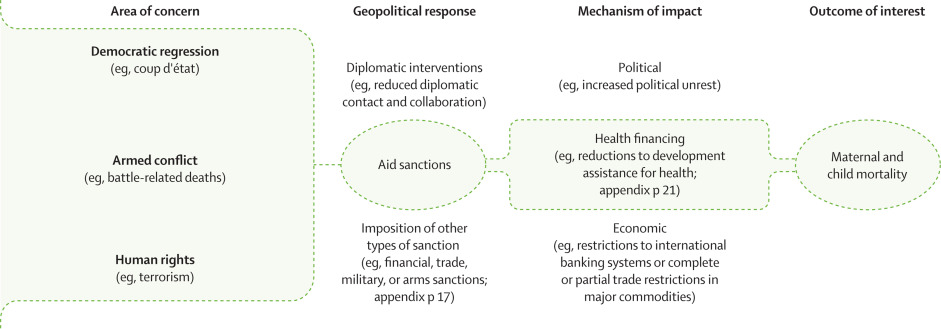

## Health (Gibson et al., 2025)

**Sample**

- 67 LMICs targeted by 88 unique aid sanction events (median duration: 5 years)
- 66 LMICs never sanctioned
- Infant, under-5, and maternal mortality declined 2.6%, 3.2%, 2%

## Health (Gibson et al., 2025)

**Research Design**

- Difference-in-differences
- Country and year fixed effects, country-specific time trends, and multiple control variables
- Sensitivity analyses, entropy balancing

## Health (Gibson et al., 2025)

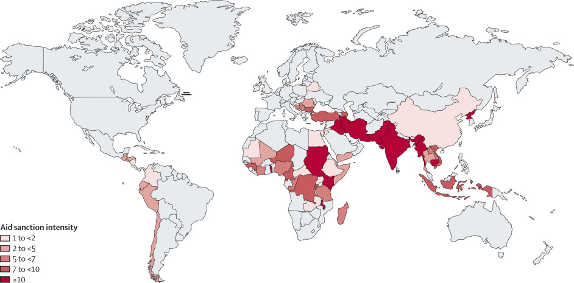

## Health (Gibson et al., 2025)

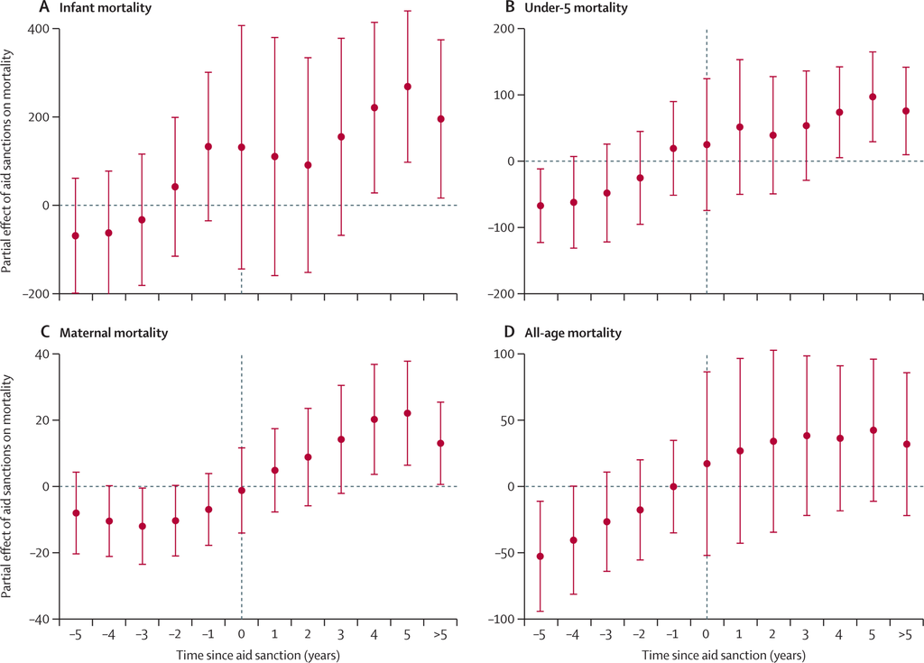

## Health (Gibson et al., 2025)

**Findings**

- Aid sanctions reduced ODA by $213m per year; DAH by $16.42m
- Sanctions negate 30% of overall improvements in infant and under-5 mortality
- Increased infant, under-5, and maternal mortality by 3.1%, 3.6%, 6.4%
- 129.3 infant deaths, 47.1 under-5 deaths, 10.9 maternal deaths per 100k births

## Democracy and governance

**Does Democracy promotion work?**

- Non-trivial amount of democracy aid sounds stupid (workshops, capacity building, cultural programs)
- Recipient country behavior suggests that enough of it does work…

## Democracy and governance

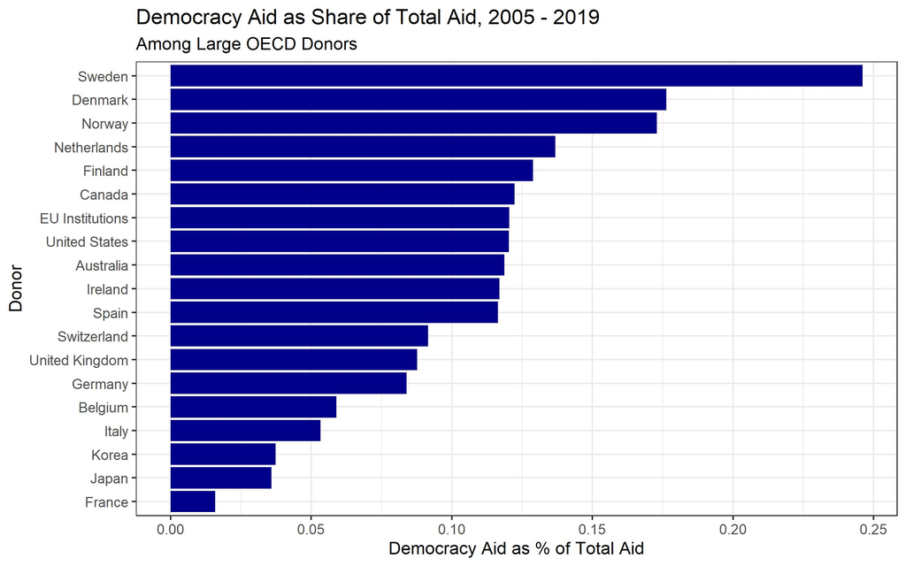

## Democracy and governance

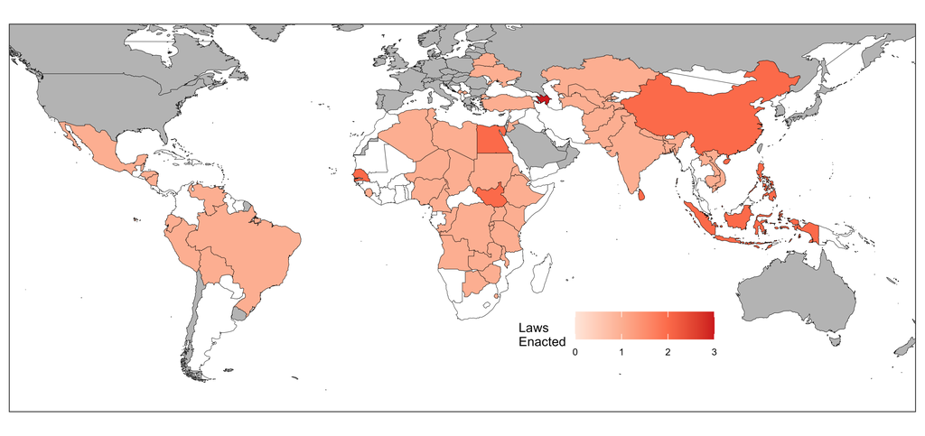

## Democracy and governance

**Does Democracy promotion work?**

- U.S. aid withdrawal is already having a massive chilling effect on domestic civil society
- U.S. has provided an umbrella of protection for NGOs (esp partners) in repressive countries

## Democracy and governance

**Serbia: U.S. has restrained Vucic from attacking NGOs**

- 2020: [Probe of NGO finances](https://apnews.com/general-news-7733ba98001cc18cd26cc78fc83615a8)
  - Investigation into anti-corruption and advocacy NGOs
  - Accusations of money laundering and terrorist financing
  - Public and private criticism by U.S. embassy and diplomats
- 2025: [Decimation of NGOs](https://apnews.com/article/serbia-usaid-prosecutors-civil-society-probe-02af3400071175e0c4b717fb6b273493)
  - Feb 2: Musk calls USAID a criminal organization
  - Feb 25: Raids, corruption charges, and exile

## Democracy and governance

- [Carnegie and Marinov (2017)](https://onlinelibrary.wiley.com/doi/full/10.1111/ajps.12289) use random variation in aid to show positive effect on democracy
- [Wright (2009)](https://onlinelibrary.wiley.com/doi/full/10.1111/ajps.12289) uses panel data to show conditionality increases democracy
- [Finn and Tarp (2016)](https://www.sciencedirect.com/science/article/pii/S030438781500111X) us dynamic panel estimators to show that governance aid increases democracy
- Democracy aid works, but we don’t necessarily know how/why; effect is small and ephemeral

## Soft Power

**Does aid win hearts and minds (soft power)?

- Aid improves health and education outcomes
- Recipients seem to know who gives aid
- Aid often comes with conditionality and corruption
- [Andrabi and Das (2017)](https://direct.mit.edu/rest/article/99/3/371/58451/In-Aid-We-Trust-Hearts-and-Minds-and-the-Pakistan) use spatial data to show that disaster relief in Pakistan improved trust in US and Europe

## Soft Power

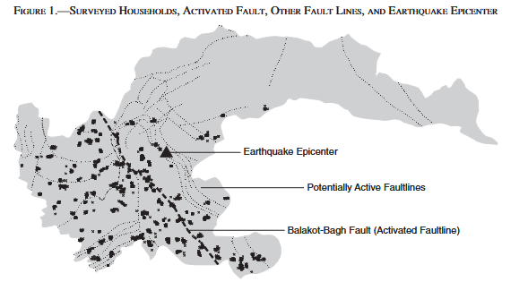

## Soft Power

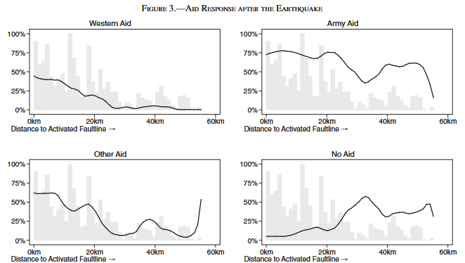

## Soft Power

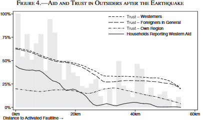

## Soft Power

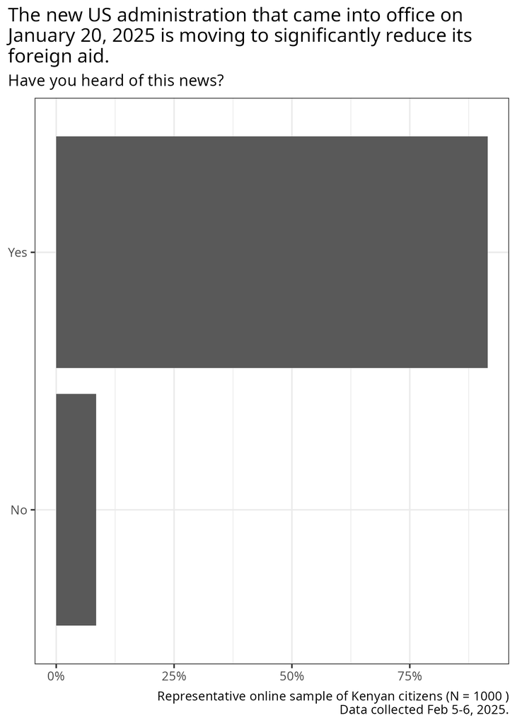

## Soft Power

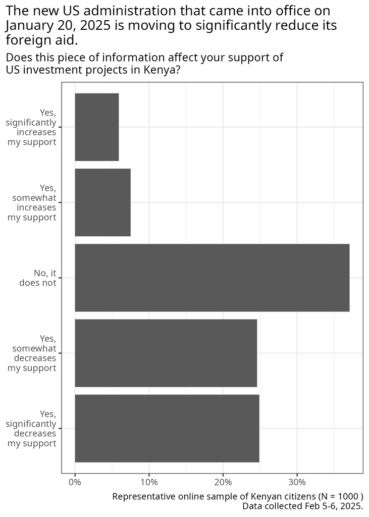

# Appendix

## Research Design

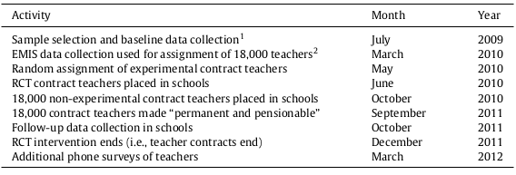

## Research Design

- Compliance
  - NGO implementation (+)
  - Local hiring (+)
  - Higher salaries (+)
  - Small class size reduction
- Attrition

## Findings

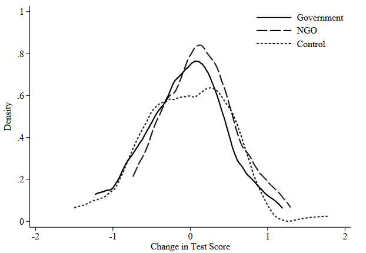

## Findings

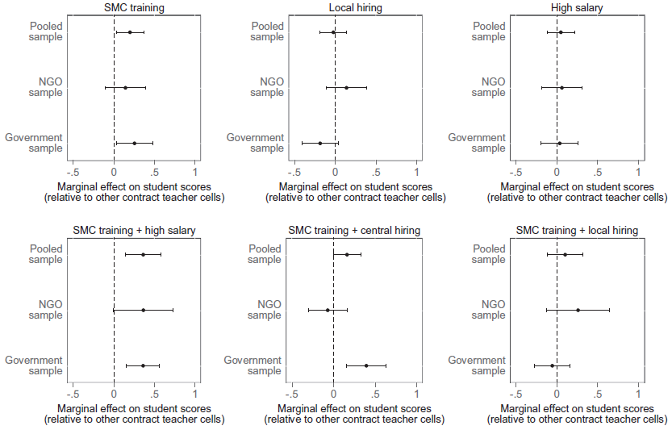

https://carolina-torreblanca.github.io/psci3200-globaldev-main/

Bates, Robert H. 1981. *Markets and States in Tropical Africa: The Political Basis of Agricultural Policies*. Univ of California Press.

Brass, Jennifer. 2014. “Blurring the Boundaries: NGOs, the State, and Service Provision in Kenya.” *The Politics of Non-State Welfare*.

———. 2016. *Allies or Adversaries: NGOs and the State in Africa*. Cambridge University Press. https://doi.org/https://doi.org/10.1017/CBO9781316678527.

Brass, Jennifer N. 2012. “Why Do NGOs Go Where They Go? Evidence from Kenya.” *World Development* 40 (2): 387–401.

Chirwa, Danwood M. 2016. “Access to Medicines and Health Care in Sub-Saharan Africa: A Historical Perspective.” *Md. J. Int’l L.* 31: 21.

Fafchamps, Marcel, and Trudy Owens. 2009. “The Determinants of Funding to Ugandan Nongovernmental Organizations.” *The World Bank Economic Review*.

Green, A, J Shaw, F Dimmock, and Cath Conn. 2002. “A Shared Mission? Changing Relationships Between Government and Church Health Services in Africa.” *The International Journal of Health Planning and Management* 17 (4): 333–53.

Herbst, Jeffrey. 2000. *States and Power in Africa: Comparative Lessons in Authority and Control*. Princeton University Press.

Hoffman, Barak D, and Clark C Gibson. 2005. “Fiscal Governance and Public Services: Evidence from Tanzania and Zambia.” *San Diego: Department of Political Science, University of California, San Diego*.

Jamali, Tiyesere Mercy. 2014. “Are Malawian Adults Turning Pink? Exploring Public Opinion on Women’s Political Leadership.” *Afrobarometer Briefing Paper* 126.

Jennings, Michael. 2014. “Bridging the Local and the Global: Faith-Based Organisations and the Emergence of the Non-State Provider Sector in Tanzania.” *The Politics of Non-State Welfare*.

Jivani, Razeen. 2010. “What are the Impacts of Non-Governmental Organizations on the Lives of the Citizens of Tanzania?”

Kapur, Devesh, and Dennis Whittle. 2009. “Can the Privatization of Foreign Aid Enhance Accountability.” *NYU Journal of International Law & Politics* 42: 1143.

Munthali, AC, H Mannan, M MacLachlan, L Swartz, CM Makupe, and C Chilimampunga. 2015. “Non-use of Formal Health Services in Malawi: Perceptions from Non-users.” *Malawi Medical Journal* 26 (4): 126–32.

Reinikka, Ritva, and Jakob Svensson. 2010. “Working For God? Evidence From A Change In Financing Of Nonprofit Health Care Providers In Uganda.” *Journal of the European Economic Association* 8 (6): 1159–78.

Troesken, Werner. 2001. “Race, Disease, and the Provision of Water in American Cities, 1889–1921.” *The Journal of Economic History* 61 (3): 750–76.

Tumwesigye, Tonny. 2013. “Health Service Delivery by the PNFP Subsector in Uganda.” Uganda Protestant Medical Bureau.

Young, Crawford. 1988. *The African Colonial State in Comparative Perspective*. Yale University Press.